# Lec7 RMarkdown

## RMarkdown and `knitr`

Reference

- [*R Markdown: The Definitive Guide*](https://bookdown.org/yihui/rmarkdown/markdown-syntax.html), Yihui Xie, J. J. Allaire, Garrett Grolemund. A free online version of this book can be found at https://bookdown.org/yihui/rmarkdown/markdown-syntax.html
- [*R Markdown Cookbook (draft)*](https://bookdown.org/yihui/rmarkdown-cookbook/), Yihui Xie, Christophe Dervieux. A free online version can be found at https://bookdown.org/yihui/rmarkdown-cookbook/
- Yihui Xie’s webpage about `knitr`: https://yihui.org/knitr/options/#code-evaluation
- cheatsheet: https://rstudio.com/wp-content/uploads/2016/03/rmarkdown-cheatsheet-2.0.pdf
- reference guide/cheatsheet: https://rstudio.com/wp-content/uploads/2015/03/rmarkdown-reference.pdf

## Introduction

- Markdown language is a system of syntax rules by which a user, when typing a text, not only controls the content of the text, but also specifies with additional symbols/commands the way output text should appear. For example, if you type

`*this is italic*`

the text will render as: *this is italic*

- So, a simple syntax (in this case wrapping the text around `*` symbols) helps you improve appearance of the text, just like an editor of a journal would markup how the text in an article should appear.
- The text in markdown language is readable as-is, without looking like it has been marked up with tags or formatting instructions, i.e. unlike text formatted with a markup language such as HTML or RTF.
- From the original markdown language created by John Gruber in collaboration with Aaron Schwartz, various versions/implementations were created as a need for a further control of the text in various disciplines. One of them is RMarkdown, which is capable of inserting R code and its output into plain markdown.
- Pandoc is a software and a markdown language that can convert text to various formats (html, pdf, word, rtf, etc.). Rmarkdown is based on Pandoc, with additional syntax and rules about marking up the appearance of R codes (as well as codes in other languages) and their outputs. The software (i.e. R package) that is responsible to “knitting and weaving” R code and its output into Pandoc markdown before converting everything into a single file of desireable format, is called `knitr`.

The best way to get started is by examining a template. To do that, in the upper left corner of RStudio dashboard, choose `File` \(\longrightarrow\) `New File` \(\longrightarrow\) `RMarkdown...` If you want to create a PDF file, you need to make sure that Latex was previously installed. Choose the format; the default is HTML; we will mostly use PDF, but ocasionally HTML, as well. Click `OK`. Your temporary Rmarkdown file (.Rmd) has been created. At the top of the file, you see couple of lines wrapped by `---`. This is a YAML section (see below). If you chose to create `pdf`, the last of the lines wrapped by `---` is `output: pdf_document`. If you chose html, you will see `output: html_document`.

Before converting it into pdf (or html), you need to save your temporary Rmd file, after which it is not temporary anymore. Then, to convert Rmd file to pdf (or html), you would need to “knit” it by clicking on `Knit` button or the dropdown menu next to the `Knit` button. In fact, if you see `output: pdf_document` in your yaml section, then clicking on `Knit` will automatically produce the pdf file, but if you want html, you would choose html from dropdown menu. Similarly works with `output: html_document`: the `Knit` button would produce html, but you can also choose to create pdf by choosing it from the dropdown menu. Whatever your choice is, clicking on `Knit` again would keep producing/updating the same format as in the previous run until you choose a different format from the dropdown menu.

## Basic Components; YAML

The YAML section tells `knitr` some basic information about format of the pages, title, author, and file format. In fact, this part is written in a serialization language, called YAML. Unlike markup languages, meant for explaining how text should be written, the purpose serialization languages are to enable humans to quickly and easily type in data or information. Apart from YAML, another frequently used serialization language is JSON. Rmarkdown uses YAML. You do NOT need to know anything about Yaml, and can easily google if you need to adjust your pages. According to the [story](https://stackoverflow.com/questions/6968366/if-yaml-aint-markup-language-what-is-it) told by Ingy döt Net (one of the cofounders of the language), YAML was initially meant to be the acronym for Yet Another Markup Language, but once the authors realized turned into a serialization language, they decided this to be a recursive acronym for YAML Ain’t Markup Language (they liked the name and already acquired https://yaml.org/)

## Chunk Options

- Reference: *R for Data Science*, H. Wickham, G. Grolemund

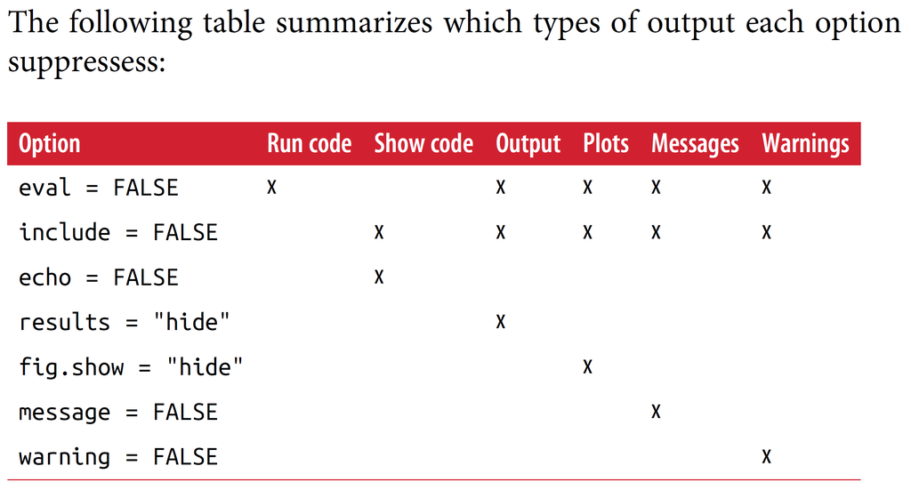

## Chunk Options

You can set up default chunk options, which define default features of codes that are to be executed. For details, check out https://yihui.org/knitr/options. Most useful options are for

- text output: https://yihui.org/knitr/options/#text-results
- code evaluations: https://yihui.org/knitr/options/#code-evaluation
- plots/figures: https://yihui.org/knitr/options/#plots
- animation: https://yihui.org/knitr/options/#animation

**Important:** When you knit Rmd file, a new environment is created for code chunks in the Rmd file. So, you cannot directly use variables from your console (i.e. from Global Environment). In addition, you need to be cautious about directories of files you want to use. In order to grab variables from Global Environment, you need to change working directory in Rmd file. This is done programmatically, as a part of a code chunk in the Rmd file. Similarly, if your Rmd file already contains a path to some directory and you don’t want to change that, you still need to change directory of current, working enironment.

## Inline R Code

Use `` `r `` `<code here>` `` ` `` for inline R code. These quotes are called backticks and can be found on the button where `~` is (left from the button for 1). For example, suppose you previously defined a vector

```r
x = c(2.2, 7, 4, -6.2)
```

whose mean is

```r
mean(x)
```

```
[1] 1.75
```

If you type the following:

The mean of the vector `` `x` `` is `` `r `` `mean(x)` `` ` ``

in the Rmd file, it will render as:

The mean of the vector `x` is 1.75

This makes your Rmd file/report very flexible and reproducible. If you need to update your vector `x` (for example, if it is a part of a weekly report, or if you made a typo in obtaining the vector `x`), you don’t need to change or update the mean of `x` manually. It is done automatically, when you knit the Rmd file, after updating `x`.

## Inline Text

Some text formatting (such as italicized, bold face, underlined etc.) can be done in Rmarkdown either by using markdown syntax, or latex syntax, or html syntax. However, keep in mind that syntaxes of all these text scripts/software are written independently of each other, and it happens not so rarely that there is a conflict of syntax. In such situations Pandoc and Rmarkdown either ignore such a syntax or try (automatically) to resolve these conflicts.

**Important**

A general rule of thumb is to use markdown syntax (instead of latex or html) as much as possible, since some latex syntax will not work if you want to generate html, and some html syntax will not work if you need to generate a pdf file.

The simpler the elements in your document are, the more likely the it can be converted as desired to different formats. If you heavily tailor R Markdown to a specific output format (e.g., LaTeX), you are likely to lose the portability, because not all features in one format work in another format.

Inline text will be

- *italic*, if surrounded by asterisks or underscore; for example, both `*this is italic*` and `_this is italic_` will look like: *this is italic*. If you are used to latex, you can also use the latex command `\textit{}`. For example, `\textit{this is italic}` will render as: *this is italic*. In HTML, you can write `<em>this is italic</em>`.
- **bold**, if surrounded by double asterisks; for example, `**this is bold**` will look like: **this is bold**. Alternatively, if you are used to latex, you can use latex command `\textbf{}`. For example, `\textbf{this is bold}` renders as: **this is bold**. In HTML, you can type `<b>this is bold</b>`.
- both *bold and italic*, if surrounded by tripple asterisks; for example, `***this is both bold and italic***` looks like: *this is both bold and italic*
- underlined seems not to have markdown syntax; instead, you can use the latex command `\underline{}`; for example, if you type `\underline{this is underlined}` in Rmd file, the corresponding output in the pdf/html will be: this is underlined. In HTML, type `<u>this is underlined</u>`.
- in subscript, if surrounded by tilde (~); for example, `X~n~` renders as X<sub>n</sub>, while `H~2~SO~4~` looks like H<sub>2</sub>SO<sub>4</sub>
- in superscript, if surrounded by carets (^); for example `R^ij^` renders as R<sup>ij</sup>.

If you want to include certain R command as inline text so that its font is the same as in RStudio console (to really look like a code text), you can use a pair of backticks, just like for executing R code in the text, but do NOT start with “r”. For example, if you type `` ` ``install.packages(“dplyr”)`` ` `` it will look like: `install.packages("dplyr")`.

Also, \(n\) literal backticks, use at least \(n+1\) backticks outside. For example in order to produce `` `install.packages("dplyr")` `` in the previous paragraph, I typed

`` `` `install.packages("dplyr")` `` ``

in the Rmarkdown file. So, the backticks at the beginning and at the end, were surrounded by double backticks, with space in between.

## New Line

If you want to break the line and continue typing text in a new line, you need double Enter button, to make one blank line in between two lines of text. For example, the following two lines were separated by one blank line in between them:

This is the first line.

This is the second line.

If you don’t like too much space between these two lines, you can use latex command `\newline` at the end of the first line. So, if you type This is the first line `\newline` in the first line (and no space between the two lines), it will render as:

This is the first line. This is the second line.

## New Page

To break a page and move to a new page, use the latex command `\newpage` at the place in the file where you want to enforce the page break.

## Hyperlinks

Hyperlinks are created using the syntax `[text](link)`.

For example, the hyperlink [RStudio webpage](https://www.rstudio.com) (click to check it’s indeed hyperlink) in this pdf file is created by typing `[RStudio webpage](https://www.rstudio.com)` in the Rmarkdown file.

**NOTE:** By default, the color of links is black. To make the link be of certain color (say, blue), you need to declare it in Yaml section at the beginning of your Rmd file. Between the pair of `- - -` which indicates Yaml section, insert without indentation the following command: `urlcolor: blue`

If you want the text to be the same as link, instead of `[text](link)`, you can just write `<link>`. For example, the RStudio webpage used above can be hyperlinked as `<https://www.rstudio.com>` So, after rendering, in pdf/html file it looks as: https://www.rstudio.com.

## Inserting Images

There are several ways to insert image:

- using markdown command: `![caption](path/to/your/image)`
- using R code chunk with `knitr::include_graphics()`
- using latex command

The first way is the simplest, but it seems it gives less control over how the image will render. As you can see, the command is similar to that of hyperlink: just add an exclamation mark, i.e.

`![caption](path/to/your/image)`

In case when creating a pdf file, sometimes (especially if the image is big) after rendering, the image shows up before the text that preceded the command

`![caption](path/to/your/image)`

or at the beginning of the page, which is probably not what you want.In some of these occasions putting the header `##`, before the image command may fix the floating issue. However, this doesn’t work always. Another possible way to fix the problem is by resizing the image using, for example `![caption](path/to/your/image){width=60%}` (no spaces around `=` sign).

Example: the following command inserts the following image from the same folder where the Rmd code file is.

`![Taken from https://animals.net/panda-bear](panda-bear.jpg){width="400" height="250"}`

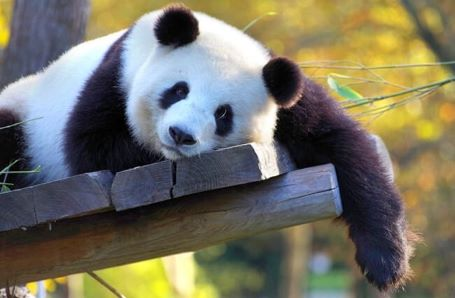

Taken from https://animals.net/panda-bear

Another way to insert image is using a code chunk. This gives more control over rendering, including the control over figure’s position. For, example.

`` ```{r, echo=FALSE, out.width = "0.4 \\textwidth", fig.align="center", fig.pos='h', ``

```
                  fig.cap = "Taken from https://animals.net/panda-bear.jpg"}
```

`knitr::include_graphics("panda-bear.jpg")`

`` ``` ``

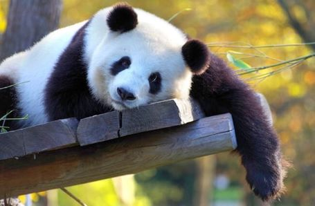

Taken from https://animals.net/panda-bear

**Remark:** The option that controls image/figure position is `fig.pos='h'` (`h` = “here”). You can also use `t` = “top”, `b` = “bottom”.

## Footnotes

Footnotes are made using `^[footnoted text]` right after the text which you want to be marked with the foodnote. For example, to have in pdf/html file the following footnoted text:

We will create interactive graphs using `shiny`<sup>1</sup>

with the footnote “Shiny is an R package to be introduced later” (check out the footnote at the bottom of this page),

you should type the following in the Rmd file:

We will create interactive graphs using `` ` ``shiny`` ` `` `^[`Shiny is an R package to be introduced later`]`

If you have multiple footnotes, you don’t need to worry about enumeration, as it is done for you automatically.

## Commenting

RMarkdown uses html convention for commenting text. Whichever comment you want to make (for yourself or other programmer), you should wrap it in between `<!--` and `-->`. For example, if in the Rmd file you type

`<!--`

This text will not be visible, nor this code

`` ```{r} ``

`x = c(1,2,3,4)`

`mean(x)`

`` ``` ``

`-->`

it will not be visible in the pdf/html file.

## Tables

There are three basic ways to create a table, using:

- `kable` function from `knitr` package to create a simple table.
- `xtable` package
- `stargazer` package (for summary statistics tables)

For example, the data frame

```r
mtcars[1:6,1:7]
```

```
                   mpg cyl disp  hp drat    wt  qsec
Mazda RX4         21.0   6  160 110 3.90 2.620 16.46
Mazda RX4 Wag     21.0   6  160 110 3.90 2.875 17.02
Datsun 710        22.8   4  108  93 3.85 2.320 18.61
Hornet 4 Drive    21.4   6  258 110 3.08 3.215 19.44
Hornet Sportabout 18.7   8  360 175 3.15 3.440 17.02
Valiant           18.1   6  225 105 2.76 3.460 20.22
```

can be presented in a table using the following command.

```r
knitr::kable(mtcars[1:6, 1:7], caption='A subset of mtcars')
```

A subset of mtcars

|  | mpg | cyl | disp | hp | drat | wt | qsec |
| --- | --- | --- | --- | --- | --- | --- | --- |
| Mazda RX4 | 21.0 | 6 | 160 | 110 | 3.90 | 2.620 | 16.46 |
| Mazda RX4 Wag | 21.0 | 6 | 160 | 110 | 3.90 | 2.875 | 17.02 |
| Datsun 710 | 22.8 | 4 | 108 | 93 | 3.85 | 2.320 | 18.61 |
| Hornet 4 Drive | 21.4 | 6 | 258 | 110 | 3.08 | 3.215 | 19.44 |
| Hornet Sportabout | 18.7 | 8 | 360 | 175 | 3.15 | 3.440 | 17.02 |
| Valiant | 18.1 | 6 | 225 | 105 | 2.76 | 3.460 | 20.22 |

In addition, one can also use the package `xtable`. The following code…

`` ```{r, results='asis'} ``

```
library(xtable)
options(xtable.comment = FALSE)
print(xtable(mtcars[1:6, 1:7],
             caption="Table using xtable package"),
      align='center',type='latex')
```

`` ``` ``

… produces the same table as above (don’t forget `results='asis'`).

**Remark:** Apart from `type='latex'`, which is more suitable to pdf files, one can use `type='html'`, which is more suitable to html files.

**Remark:** The command `options(xtable.comment = FALSE)` supresses printing some info about the table prior to the appearance of the table.

For a quick table with summary statistics of data (or of a statistical model), a `stargazer` package can be used. For example, here is a summary statistics for the `mtcars[1:6,1:7]` data (again, use `results='asis'` as a chunk option).

```r
stargazer::stargazer(data=mtcars[1:6,1:7], header=FALSE, type = "latex",
 title = "Table created by stargazer")
```

[output not shown]

**Remark:** Setting `header=FALSE` supresses the table info to print before the table.

## Latex

We give a very, very brief survey of Latex syntax. For more comprehensive ones, see any of the numerous lists of symbols that can be found online; for example:

- https://en.wikipedia.org/wiki/Wikipedia:LaTeX_symbols
- https://artofproblemsolving.com/wiki/index.php/LaTeX:Symbols

Latex text is wrapped in a single `$` sign on both sides of the text (for inline text) or in a double `$$` for text in a separate line. For example, the text

`${24 \over 3} = 8$`

renders as

\({24 \over 3} = 8\).

The alternative syntax for `${24 \over 3}$` is `\frac{24}{3}`. This small inline fraction is in a (default) `\textstyle` mode, but if we use `\displaystyle` and write

`$\displaystyle {24 \over 3} = 8$`, it renders as

\(\displaystyle {24 \over 3} = 8\).

As per double dollar, the text `$${24 \over 3} = 8$$` renders as \[{24 \over 3} = 8\] i.e. in a separate line, centered, and in the displaystyle mode (by default).

**Important**: As mentioned earlier, pandoc and Rmarkdown try to make sense of a mix of syntaxes of several languages. Consequently, sometimes it doesn’t compile even with a valid latex syntax, simply because it understands it in a different (non-latex) way. In particular, in some circumstances (for example, when there is `\` symbol in between `$` characters), Rmarkdown does not compile if the string of characters wrapped by `$` starts or ends with space. For example, `$\beta $` does not compile, but `$\beta$` does, even though in plain latex (i.e. in a tex file) both ways are valid and give the same output. Therefore, when writing latex text in Rmarkdown, you should make the text “tightly” wrapped by `$`’s.

Here is a syntax for some commonly used symbols:

`$\cdot, \cdots, \dots, x^2, x^{22}, x_a^{22}, x_{ab}^{22}$` (or `$x^{22}_{ab}$`), `$\bar{X}, \bar{X}_n, \hat{\Theta}$`

which renders as

\(\cdot, \cdots, \dots, x^2, x^{22}, x_a^{22}, x_{ab}^{22}\) (or \(x^{22}_{ab}\)), \(\bar{X}, \bar{X}_n, \hat{\Theta}\)

Greek letters

`$\alpha, \beta, \beta_0, \epsilon, \varepsilon, \phi, \varphi, \chi^2_d$`

render as

\(\alpha, \beta, \beta_0, \epsilon, \varepsilon, \phi, \varphi, \chi^2_d\)

If you want a bit more space in \(\alpha, \beta\), type `\,` between them, i.e. type

`$\alpha, \, \beta$` to get

\(\alpha, \, \beta\).

For more space, add more `\,`. For even more space, type `\alpha, \hspace{0.5cm} \beta` to get

\(\alpha, \hspace{0.5cm} \beta\).

The horizontal space command `\hspace{}` also accepts `in` instead of `cm`, which of course, is for inches. Vertical space between lines is made using `\vspace{0.5cm}`, or any other quantity in `cm` or `in`.

Now, we provide a gallery of latex text outputs for some common math symbols, as well as the syntax that produced them.

1. \(y = \beta_0 + \beta_1\cdot x + \varepsilon\), where \(\varepsilon \sim \mathcal{N}(\mu=0; \,\,\sigma^2)\)
2. \(\displaystyle MSE = {SSE \over n-2} = {1\over n-2} \sum_{i=1}^n (y_i - \hat{y}_i)^2\)
3. \(\displaystyle \int_0^{\infty}e^{-2x}dx = \left(-{1\over 2}\right) e^{-2x}\Big|_{x=0}^{x\to\infty} = \left(-{1\over 2}\right)(0 - e^0) = {1\over 2}\)

Their syntax is (note the “tightness” of wrapping with `$`):

1. `$y = \beta_0 + \beta_1\cdot x + \varepsilon$, where $\varepsilon \sim \mathcal{N}(\mu=0; \,\,\sigma^2)$`

2. `$\displaystyle MSE = {SSE \over n-2} = {1\over n-2} \sum_{i=1}^n (y_i - \hat{y}_i)^2$`

3. `$\displaystyle \int_0^{\infty}e^{-2x}dx = \left(-{1\over 2}\right) e^{-2x}\Big|_{x=0}^{x\to\infty} = \left(-{1\over 2}\right)(0 - e^0) = {1\over 2}$`

4. \(\forall a, b \in \mathbf{R}\) with \(a\neq b\), we have: \(\displaystyle {a^2 - b^2 \over a-b} = a+b\)

5. \(\sqrt{\sum_{i=1}^n (x_i+y_i)^2} = \|x + y\| \leq \|x\| + \|y\|\)

6. \(\displaystyle \lim_{n\to \infty}P\cdot \left(1 + {r\over n}\right)^{n\,t} = P\, e^{rt}\)

Their syntax is:

4. `$\forall a, b \in \mathbf{R}$ with $a\neq b$, we have: $\displaystyle {a^2 - b^2 \over a-b} = a+b$`

5. `$\sqrt{\sum_{i=1}^n (x_i+y_i)^2} = \|x + y\| \leq \|x\| + \|y\|$`

6. `$\displaystyle \lim_{n\to \infty}P\cdot \left(1 + {r\over n}\right)^{n\,t} = P\,e^{rt}$`

## HTML

- [w3schools.com](https://www.w3schools.com/html/default.asp), a good way to quickly learn HTML (as well as CSS and JavaScript)
- another good guide to HTML http://www.simplehtmlguide.com/
- cheat sheet http://www.simplehtmlguide.com/cheatsheet.php
- a cool interactive cheatsheet: https://htmlcheatsheet.com/